# Random Forest Prediction of Maize Prices

#### Introduction

Maize price estimates covering a continuous geographical area are difficult to collect: It costs a lot and takes time to collect the data. Using the price of maize at known locations and the value of spatial variables at these locations, we can create a model for predicting maize prices. Given the values of the spatial variables, the model will consequently predict the price of maize in other locations.

An ideal model should be simple enough to develop and use, yet complex enough to emulate all empirical and/or theoretical associations. Models based on the [random forest algorithm (developed by Leo Breiman)](https://link.springer.com/content/pdf/10.1023%2FA%3A1010933404324.pdf) attempts to achieve this ensemble. The random forest algorithm creates decision-trees that classify the data into predetermined classes - predetermined by the user(Supervised classification). Each decision-tree makes a classification of the data to create a set of responses; the most popular response (classification) is the final output.

#### (I) The Data

##### 1. The Maize Prices data

```r
library(raster) # Will load "sp" package as a dependency
library(rgdal)
maize.price <- read.csv("data/ethMaizePrice2011.csv")
head(maize.price, 5) #view the first 5 rows of the data
```

```
##   Woreda.Code Longitude Latitude Maize.Price_BirrKg Year
## 1       10101  37.78927 14.44675              6.410 2011
## 2       10102  38.19761 14.36849              4.815 2011
## 3       10103  38.44622 14.01280              3.330 2011
## 4       10104  38.28904 14.09540              3.435 2011
## 5       10105  37.99430 13.95832              3.100 2011
```

The longitude and latitude values of the maize price locations are in decimal degrees and based on the [WGS84](https://confluence.qps.nl/qinsy/en/world-geodetic-system-1984-wgs84-29855173.html) coordinate system. So we create an object of class “CRS” (coordinate reference system) in R, that will be used to specify this system. We then use the “data frame” and “CRS” objects, to create a shapefile whose attribute table contains the coordinates and price data. we plot the shapefile to see the distribution of the price locations and ensure they all lie within the borders of Ethiopia.

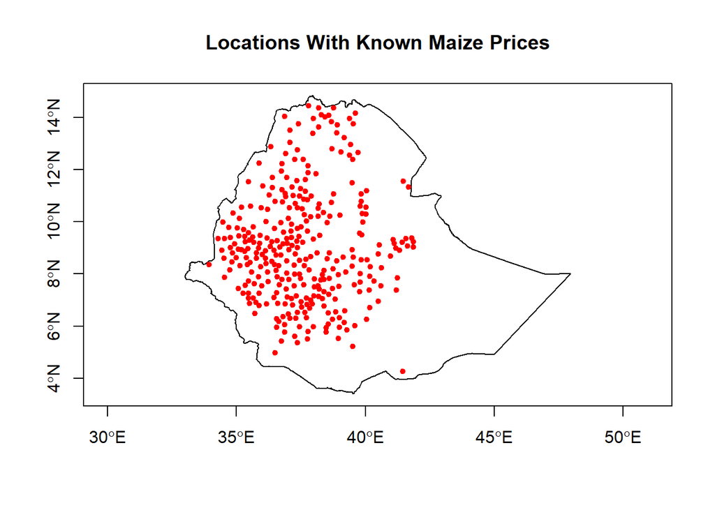

```r
# wgs84.prj: projection for coordinates in prices csv
wgs84.prj <- CRS("+proj=longlat +datum=WGS84 +no_defs +ellps=WGS84 +towgs84=0,0,0")
maizeprice <- SpatialPointsDataFrame( coords = data.frame( maize.price$Longitude, maize.price$Latitude ),
                                      data = maize.price,
                                      proj4string = wgs84.prj
                                     )

ETH_natbnd <- getData('GADM', country='ETH', level=0)
plot(ETH_natbnd, axes = TRUE, main = "Locations With Known Maize Prices")
plot(maizeprice, pch = 20, col = "Red", add = TRUE)
```

The raster files used in this exercise are in the [Lambert azimuthal equal-area projection](https://en.wikipedia.org/wiki/Lambert_azimuthal_equal-area_projection), which better preserves areas and distances compared with the WGS84 projection. We transform the projection of the maize price shapefile to match this projection, since it must share the same projection system with the rasters in any spatial process. As before, we create a Lambert Azimuthal Equal-Area (LAEA) projection object of class “CRS” (coordinate reference system) then use it to transform the coordinates to the LAEA projection.

```r
laea.prj <- CRS("+proj=laea +lat_0=5 +lon_0=20 +x_0=0 +y_0=0 +datum=WGS84 +units=m +no_defs +ellps=WGS84 +towgs84=0,0,0")

maizeprice_laea <- spTransform(maizeprice, laea.prj)
```

##### 2. Raster Data Set

###### a) Raster Data on Weather, Soil and Amenities

The raster files contain data on weather elements, soil properties and distance to infrastructure/amenities. In this exercise, these files are in a sub-directory of the working directory. You can download them [here](https://osf.io/7jkzf/). The table below gives a short description of each file and a link to the source website.

[output not shown]

We set up an empty “stack” object that will hold the rasters and assign it the Lambert azimuthal equal-area projection. Consequently, we add the rasters in the sub-directory (named “rasters” in this exercise) to the stack through a “for” loop.

```r
rasterstack <- stack()
crs(rasterstack) <- laea.prj # raster::crs differs with sp::CRS

rasterlist <- list.files(path = "./rasters",
                         pattern = "*.tif$",
                         full.names = TRUE) # Character vector of relative filepaths
for (rasterpath in rasterlist) {
      rasterfile <- raster(rasterpath)
      rasterstack <- addLayer(rasterstack, rasterfile)
    }
```

###### b) Add Latitude and Longitude Rasters

We add longitude and latitude rasters to the stack so that our model considers location in its prediction. The longitude and latitude rasters will have the longitude values and latitude values respectively as the cell values. We use one raster from the stack created earlier as a reference, to ensure the latitude and longitude rasters have the same properties.

```r
refrenceraster <- rasterstack[[1]]
```

```r
# Step 1
natbnd_laea <- spTransform(ETH_natbnd, laea.prj)

# Step 2
natbnd.raster <- rasterize(natbnd_laea, refrenceraster)

# Step 3
latitudes <- xFromCell(natbnd.raster, 1:length(natbnd.raster))
longitudes <- yFromCell(natbnd.raster, 1:length(natbnd.raster))

# Step 4
natbnd.raster.lati <- natbnd.raster.long <- natbnd.raster
values(natbnd.raster.lati) <- latitudes
values(natbnd.raster.long) <- longitudes

# Step 5
names(natbnd.raster.long) <- "Longitude"
names(natbnd.raster.lati) <- "Latitude"
rasterstack <- stack(rasterstack, natbnd.raster.long, natbnd.raster.lati)
```

```r
names(rasterstack)
```

```
##  [1] "BIO1"      "BIO12"     "BIO15"     "BIO7"      "CEC"
##  [6] "DCELL"     "DOR1"      "DOR2"      "DOWS"      "DPARK"
## [11] "DPOP1"     "DPOP2"     "EVI"       "LSTD"      "LSTN"
## [16] "MB1"       "MB2"       "MB3"       "MB7"       "MDEM"
## [21] "NPPA"      "NPPS"      "PARA"      "PH"        "S1VV"
## [26] "SND"       "SOC"       "Longitude" "Latitude"
```

#### (II) Classification Model - Random Forest

The classification model represents the relationship between the response variable (maize prices) and prediction variables (element of feature values in the raster files). It is based on the random forest algorithm, which works by creating decision-trees that “vote” on the most popular classification. The splits (branching) in the decision-trees are determined by random subsets of the prediction variables’ values. The number of decision-trees to create, and the number of variables to consider at each split, are determined by the user. We’ll use the “randomForest” function from the “randomForest” library to create the model. We’ll accept its default value for the number of decision-trees and determine the number of variables to use in each split using the “tuneRF” function (also from “randomForest” library).

```r
library(randomForest)
```

```r
# Takes Time ~ 20 min
predict.vrbs = extract(rasterstack,
                  maizeprice_laea,
                  buffer=5000, # Meters
                  small=TRUE,
                  fun = mean)

predict.vrbs <- predict.vrbs[complete.cases(predict.vrbs),]
```

##### 1. Tune The Forest

By “tune the forest”, we mean the process of determining the optimal number of variables to consider at each split in a decision-tree. Too many prediction variables and the algorithm will over-fit; too few prediction variables and the algorithm will under-fit. We use “tuneRF” function from the “randomForest” library to get the possible optimal numbers of prediction variables. The “tuneRF” function takes two arguments: the prediction variables and the response variable.

```r
trf <- tuneRF(x=predict.vrbs, # Prediction variables
              y=maizeprice_laea@data[, "Maize.Price_BirrKg"] # Responce variable
              )
```

```
## mtry = 9  OOB error = 0.4733503
## Searching left ...
## mtry = 5     OOB error = 0.4555121
## 0.037685 0.05
## Searching right ...
## mtry = 18    OOB error = 0.4555456
## 0.03761433 0.05
```

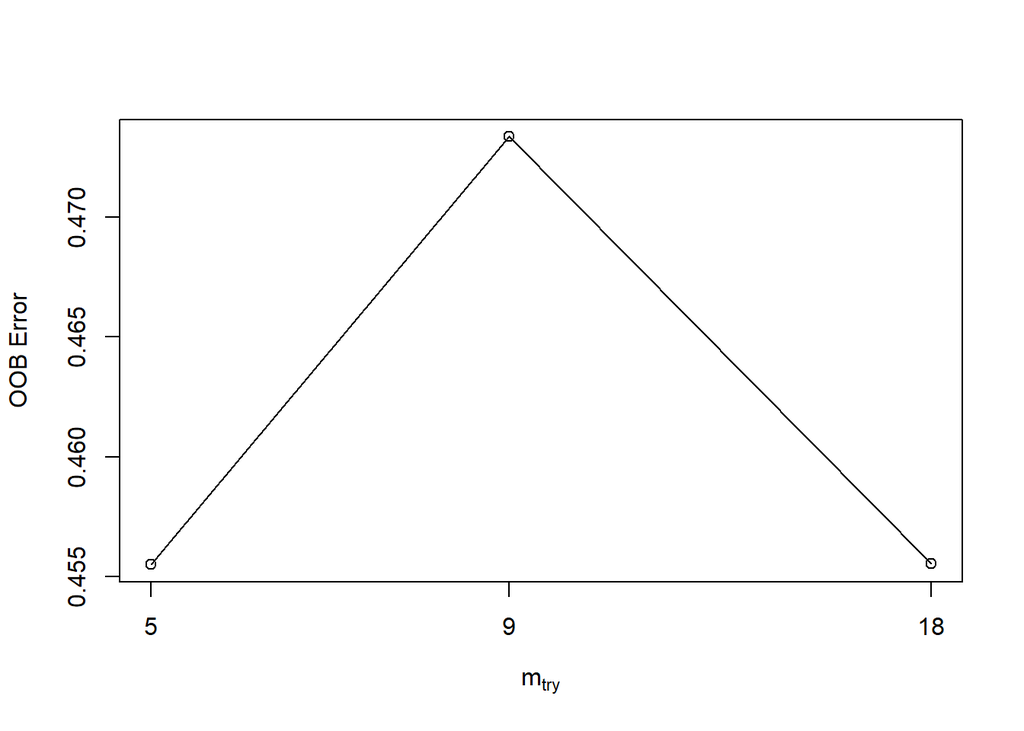

We consider the prediction error ( [Out-of-Bag error.](https://en.wikipedia.org/wiki/Out-of-bag_error) ) when selecting the optimal number, from the suggestions made by “tuneRF”.

```r
(mintree <- trf[which.min(trf[,2]),1])
```

```
## [1] 5
```

##### 2. Fit The Model

We create a model with the “randomForest” function which takes as arguments: the response variable, the prediction variables and the optimal number of variables - to consider at each split. We also get the function to rank the prediction variables based on how much influence they have in the decision-trees’ results.

```r
price.model <- randomForest(x=predict.vrbs, # Prediction variables
                             y=maizeprice_laea@data[, "Maize.Price_BirrKg"], # Responce variable
                             mtry=mintree, # Number of variables in subset at each split
                             importance = TRUE # Assess importance of predictors.
                             )
```

We can have a look at the model in detail by plotting it; A plot of the number of trees against OOB error: the error rate as the number of trees increase.

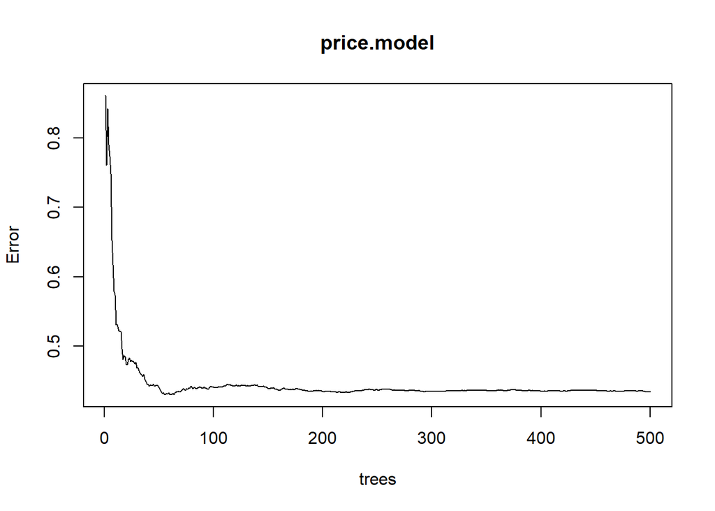

```r
plot(price.model)
```

We can have a look at each variable’s influence by plotting their importance based on different indices given by the [importance function](https://www.rdocumentation.org/packages/randomForest/versions/4.6-14/topics/importance).

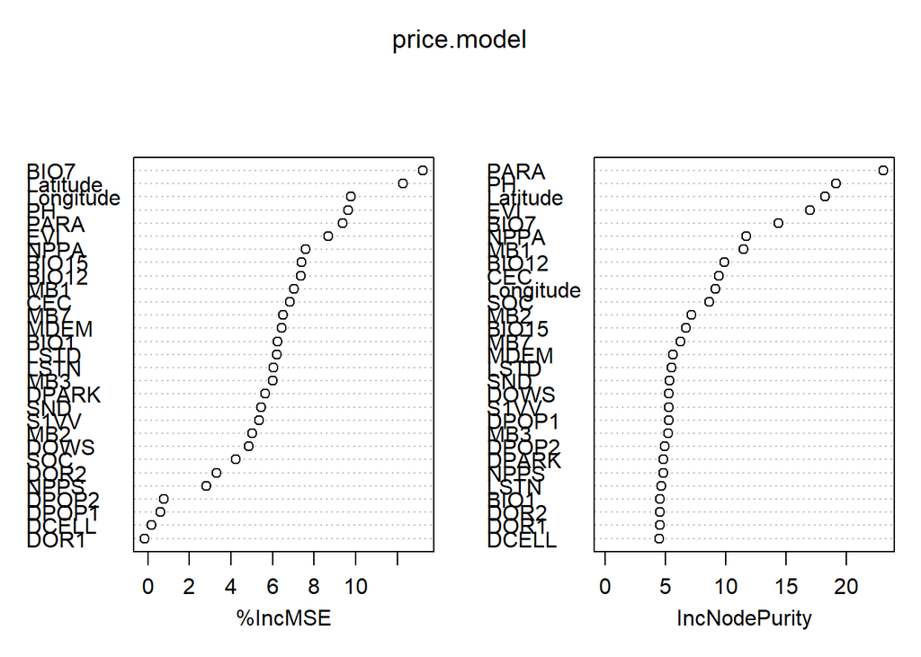

```r
varImpPlot(price.model)
```

#### (III) Price Prediction and Results Evaluation

In this section, we predict the price of maize across the country (Ethiopia) using the data prepared in section one and the model created in section two. We make the prediction via the “predict” function in the “raster” package. The function produces a raster file, which has maize prices (ETB/KG) as the pixel/cell values. Finally, we evaluate the prediction by comparing the values the model predicts with the actual prices collected.

##### 1. Price Prediction

The spatial prediction -the variables are spatial- function takes two arguments: the prediction variables and the price prediction model.

```r
# NB:Both the "stats" package(loaded as a randomForest dependency) and
# the "raster" package have a function called "predict" that can make predictions.
# Since we are dealing with spatial data, we add a prefix to the function name to
# ensure the "predict" function in the raster "package" is used.

spatial.prediction <- raster::predict(rasterstack, # Prediction variable rasters
                                      price.model # Prediction  model
                                      )            # takes time!
```

The raster of predicted maize prices is our main output; we plot it to see the maize price distribution - prices in Ethiopia Birr per Kilogram.

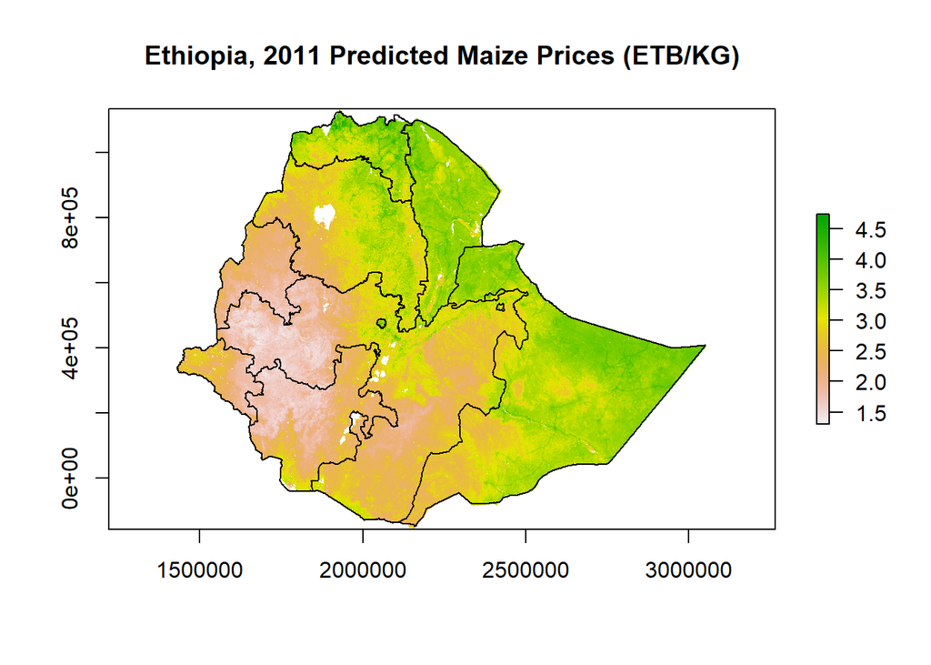

```r
# Get Tanzania Regions Shapefile
ETH_natbnd_1 <- getData('GADM', country='ETH', level=1)
# Transform to laea projection
ETH_natbnd_1_laea <- spTransform(ETH_natbnd_1, laea.prj)

#  Plot the Predicted prices and the regional boundaries
plot(spatial.prediction, main = "Ethiopia, 2011 Predicted Maize Prices (ETB/KG)")
plot(ETH_natbnd_1_laea, add = TRUE)
```

##### 2. Prediction Evaluation

To assess the predictions, we will compare the observed maize prices (the training data) with the predicted maize prices (predicted using the training data). We plot the observed and predicted values to see the trend.

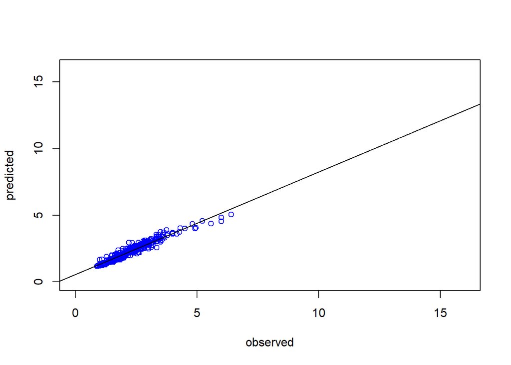

```r
# Considering that the training data, is in point form as opposed to raster,
# We will make a non-spatial prediction using the predict function in the "stats" package

non.spatial.prediction <- stats::predict(price.model, predict.vrbs)
plot(
  maizeprice_laea@data[, "Maize.Price_BirrKg"],
  non.spatial.prediction,
  col = 'blue',
  xlab = 'observed',
  ylab = 'predicted',
  xlim = c(00, 16),
  ylim = c(00, 16)
)
lm_line <- lm(non.spatial.prediction ~ maizeprice_laea@data[, "Maize.Price_BirrKg"],
              data = data.frame(maizeprice_laea@data[, "Maize.Price_BirrKg"],
                                non.spatial.prediction
                                )
              )
abline(lm_line)
```